# Monte Carlo Investigation: The Cauchy Population

Author

Pui Yin Lim

## 1. Population & Theoretical Baseline

- **Population Distribution:** Cauchy Distribution with location $x_0 = 0$ and scale $\gamma = 1$, generated via `rcauchy(n, location = 0, scale = 1)`.
- **Characteristics:** It is a continuous, symmetric, bell-shaped-looking distribution with **extremely heavy tails**.
- **Theoretical Mean (**$\mu$): **Undefined** (infinite expectation)
- **Theoretical Standard Deviation (**$\sigma$): **Undefined** (infinite variance)
- **Theoretical Standard Error (**$\text{SE}$): **Undefined** (does not scale with $\frac{1}{\sqrt{n}}$)

## 2. Expectations Before Simulation

Unlike normal, uniform, or exponential distributions, increasing the sample size $n$ (e.g., from $n = 5$ to $n = 50$) shouldn’t cause the sampling distribution to become normal or for the spread to contract. Instead, the sample mean $\bar{X}$ follows the same Cauchy distribution as the individual observations meaning extreme outliers might distort the average across all sample sizes $n$.

## 3. Simulation Setup & Execution

Simulating $B = 10,000$ Monte Carlo repetitions across sample sizes $n \in \{5, 10, 30, 50\}$ to demonstrate the total failure of the Central Limit Theorem when variance is infinite.

```r
library(tidyverse)
library(knitr)

# Create a data frame for the explanation table
cauchy_explanation_table <- tibble(
  Sample_Size = c("n = 5", "n = 10", "n = 30", "n = 50"),
  Theoretical_SE = c("Undefined", "Undefined", "Undefined", "Undefined"),
  Interpretation = c(
    "A small sample size where extreme Cauchy outliers frequently pull the sample mean in drastic directions, producing massive dispersion.",
    "An intermediate sample size. Because the population mean does not exist, increasing n fails to stabilize or narrow the spread of estimates.",
    "A larger sample size highlighting the failure of the Central Limit Theorem; extreme values continue to dominate rather than average out.",
    "The maximum investigated sample size, demonstrating that the sampling distribution retains its heavy-tailed Cauchy shape and infinite variance without converging to normal."
  )
)

kable(
  cauchy_explanation_table,
  col.names = c("Sample Size", "Theoretical SE", "Description & Interpretation"),
  align = c("c", "c", "l")
)
```

Table 1: Rationale for Sample Size Selection (Cauchy Population)

| Sample Size | Theoretical SE | Description & Interpretation |
| --- | --- | --- |
| n = 5 | Undefined | A small sample size where extreme Cauchy outliers frequently pull the sample mean in drastic directions, producing massive dispersion. |
| n = 10 | Undefined | An intermediate sample size. Because the population mean does not exist, increasing n fails to stabilize or narrow the spread of estimates. |
| n = 30 | Undefined | A larger sample size highlighting the failure of the Central Limit Theorem; extreme values continue to dominate rather than average out. |
| n = 50 | Undefined | The maximum investigated sample size, demonstrating that the sampling distribution retains its heavy-tailed Cauchy shape and infinite variance without converging to normal. |

```r
library(tidyverse)
library(moments)

# Reproducible seed using last 4 digits of student ID
student_id <- 5678
set.seed(student_id)

B <- 10000                  # Number of Monte Carlo simulations
sample_sizes <- c(5, 10, 30, 50) # Sample sizes to investigate

# Run simulation dynamically for all sample sizes using map_dfr
sim_data <- map_dfr(sample_sizes, function(n_val) {
  sample_means <- replicate(B, mean(rcauchy(n_val, location = 0, scale = 1)))
  tibble(
    n = factor(n_val, levels = sample_sizes),
    sample_mean = sample_means
  )
})
```

## 4. Visualization

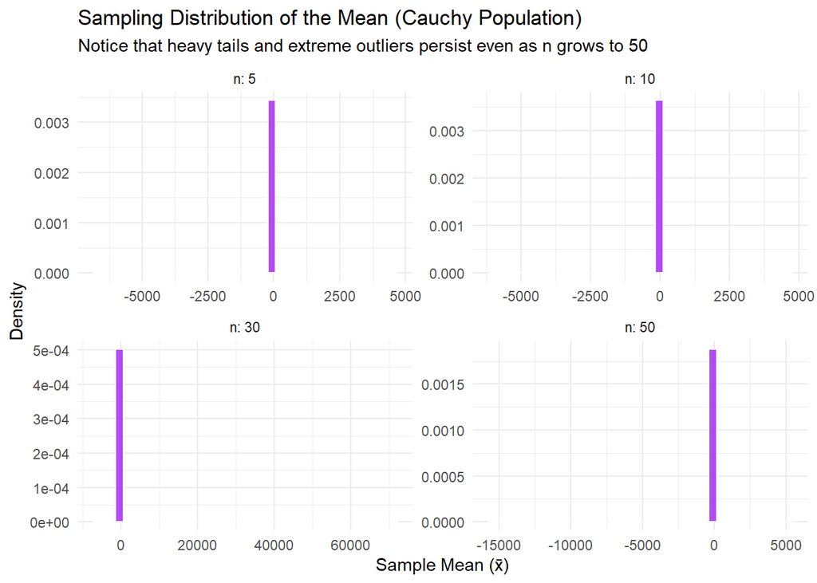

```r
ggplot(sim_data, aes(x = sample_mean)) +
  geom_histogram(aes(y = after_stat(density)), bins = 40, fill = "purple", color = "white", alpha = 0.8) +
  facet_wrap(~n, scales = "free", labeller = label_both) +
  theme_minimal() +
  labs(
    title = "Sampling Distribution of the Mean (Cauchy Population)",
    subtitle = "Notice that heavy tails and extreme outliers persist even as n grows to 50",
    x = "Sample Mean (x̄)",
    y = "Density"
  )
```

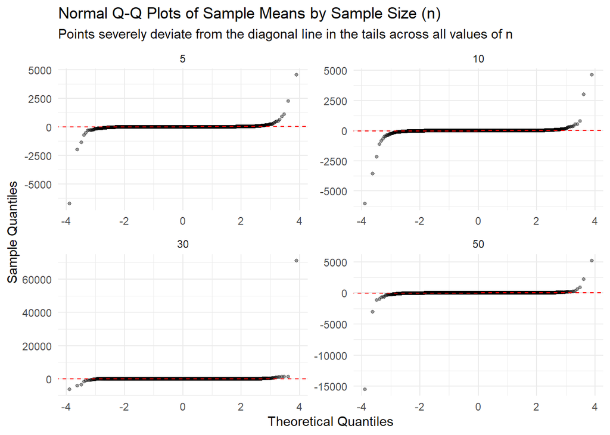

```r
library(ggplot2)

ggplot(sim_data, aes(sample = sample_mean)) +
  geom_qq(alpha = 0.4, size = 1) +
  geom_qq_line(color = "red", linetype = "dashed") +
  facet_wrap(~ n, scales = "free") +
  labs(
    title = "Normal Q-Q Plots of Sample Means by Sample Size (n)",
    subtitle = "Points severely deviate from the diagonal line in the tails across all values of n",
    x = "Theoretical Quantiles",
    y = "Sample Quantiles"
  ) +
  theme_minimal()
```

The Q-Q plots show severe, dramatic departures from the red reference line across all sample sizes. The extreme tail divergence confirms that the sampling distribution is non-normal and heavily contaminated by outliers.

## 5. Numerical Output

```r
summary_table <- sim_data %>%
  group_by(n) %>%
  summarise(
    Simulated_Mean = mean(sample_mean),
    Simulated_SD = sd(sample_mean),
    Skewness = moments::skewness(sample_mean),
    Kurtosis = moments::kurtosis(sample_mean)
  )

knitr::kable(
  summary_table,
  caption = "Comparison of Simulated Metrics for Cauchy Population (Note instability due to undefined moments)",
  digits = 4,
  align = c("c", "c", "c", "c", "c")
)
```

Comparison of Simulated Metrics for Cauchy Population (Note instability due to undefined moments)

| n | Simulated_Mean | Simulated_SD | Skewness | Kurtosis |
| --- | --- | --- | --- | --- |
| 5 | -0.0817 | 91.1933 | -27.2488 | 3654.375 |
| 10 | -0.6112 | 95.6482 | -17.2829 | 2470.310 |
| 30 | 6.0703 | 718.1872 | 97.3489 | 9662.225 |
| 50 | -1.7785 | 169.7385 | -73.5089 | 7038.057 |

**Simulated Mean:** Fluctuates wildly and remains unstable across simulation runs because the population mean does not exist.

**Simulated SD:** Does not shrink as $n$ increases. In fact, standard deviation calculations become erratic because the variance is infinite.

**Skewness and Kurtosis:** Extreme values and massive kurtosis values highlight the severe heavy-tailed nature of the Cauchy distribution that fails to converge to normality.

## 6. In Summary

**1. What does the original population distribution look like?**

The parent population is a Cauchy Distribution ($x_0 = 0$, $\gamma = 1$), which is continuous, symmetric, and bell-shaped in appearance but possesses extremely heavy tails.

**2. How quickly does the sampling distribution become approximately normal?**

It never becomes normal because the Cauchy distribution violates the finite variance condition, the Central Limit Theorem fails completely. The sampling distribution remains Cauchy-distributed for all sample sizes $n$.

**3. How does the simulated mean compare with the theoretical mean?**

The theoretical mean is undefined. Consequently, the simulated means do not stabilize around a single true value and can be heavily skewed by single extreme random draws.

**4. How does the simulated standard error compare with $\text{SE}(\bar{x}) = \frac{\sigma}{\sqrt{n}}$?**

The formula $\text{SE} = \frac{\sigma}{\sqrt{n}}$ is inapplicable because both population standard deviation ($\sigma$) and standard error are undefined. The simulated dispersion does not shrink as $n$ increases.

**5. What evidence supports your conclusion that the distribution fails to become normal?**

Histograms retain massive spread/spikes with extreme bounds, Q-Q plots show severe tail divergence away from the diagonal line, and numerical metrics like standard deviation fail to decrease with $n$.

**6. What limitations or surprises did you observe?**

The main surprise was the CLT fail, while previous distributions (normal, uniform, exponential) became smooth and narrowed down as $n$ grew, the Cauchy distribution opposed this demonstrating that finite variance is a strict requirement for asymptotic normality.